# PWM

In the circuit given below, the switches are operated using the pulse width modulation technique with a switching frequency of $1\,$kHz. The modulation voltage is $m(t)=M\,\sin (100\,\pi\,t)$, and the triangular carrier voltage is $v_c(t)$. The zero-crossings of $m(t)$ coincide with time points where $v_c(t)$ also crosses zero. Switches S1 and S4 are turned on when $m(t) > v_c(t)$, and switches S2 and S3 are turned on otherwise. The parameter values are $R=20\,\Omega$, $L=10\,$mH, and $V_{dc}=400\,$V. What is the minumum value of $M$ for which the voltage across the load $v_{BC}$ is a $50\,$Hz square wave?

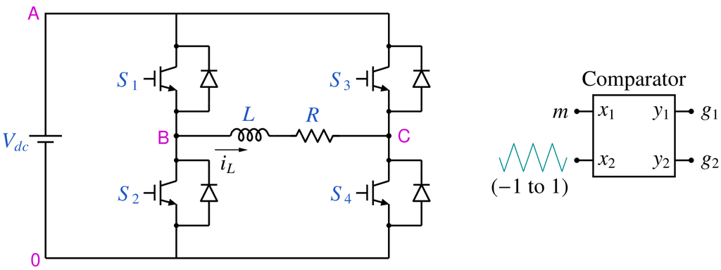

```python
from IPython.display import Image
Image(filename =r'pwm_3_fig_1.png', width=550)
```

```python
# run this cell to view the circuit file.
%pycat pwm_3_orig.in
```

We now replace the strings such as \$Vdc, \$L, with the values of our choice by running the python script given below. It takes an existing circuit file `pwm_3_orig.in` and produces a new circuit file `pwm_3.in`, after replacing \$Vdc, \$L, etc. with values of our choice.

```python
import gseim_calc as calc
s_Vdc = "400"
s_L = "10e-3"
s_R = "20"
s_f_carrier = "1e3"
s_M = "1.5" # to be changed by user
s_dt_min = "1e-6"
s_dt_nrml = "10e-6"

s_f_sin = "50"
f_sin = float(s_f_sin)

T = 1/f_sin
s_2T = ("%11.4E"%(2.0*T)).strip()
s_T = ("%11.4E"%(T)).strip()

tri_t0 = -0.25/float(s_f_carrier)
s_tri_t0 = ("%11.4E"%(tri_t0)).strip()

l = [
  ('$Vdc', s_Vdc),
  ('$L', s_L),
  ('$R', s_R),
  ('$f_carrier', s_f_carrier),
  ('$f_sin', s_f_sin),
  ('$2T', s_2T),
  ('$T', s_T),
  ('$tri_t0', s_tri_t0),
  ('$M', s_M),
  ('$dt_min', s_dt_min),
  ('$dt_nrml', s_dt_nrml)
]
calc.replace_strings_1("pwm_3_orig.in", "pwm_3.in", l)
print('pwm_3.in is ready for execution')
```

```
pwm_3.in is ready for execution
```

**Execute the following cell to run GSEIM on pwm_3.in.**

```python
import os
import dos_unix
# uncomment for windows:
#dos_unix.d2u("pwm_3.in")
os.system('run_gseim pwm_3.in')
```

```
Circuit: filename = pwm_3.in
main: calling solve_trns
Transient simulation starts...
i=0
i=1000
i=2000
i=3000
i=4000
i=5000
i=6000
GSEIM: Program completed.
```

```
0
```

The circuit file (`pwm_3.in`) is created in the same directory as that used for launching Jupyter notebook. The last step (i.e., running `GSEIM` on `pwm_3.in`) creates a data file called `pwm_3.dat`in the same directory. We can now use the python code below to compute/plot the various quantities of interest.

```
filename: pwm_3.dat
average IL: -6.5385E-03
average load voltage: -5.4045E-02
```

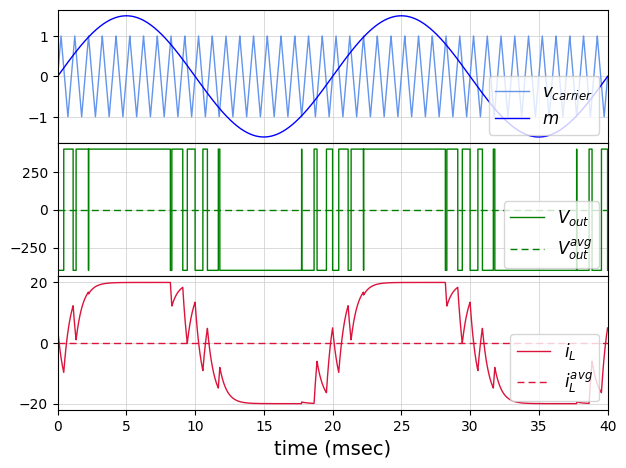

```python
import numpy as np
import matplotlib.pyplot as plt
import gseim_calc as calc
from setsize import set_size

slv = calc.slv("pwm_3.in")

i_slv = 0
i_out = 0
filename = slv.l_filename_all[i_slv][i_out]
print('filename:', filename)
u = np.loadtxt(filename)
t = u[:, 0]

v_out = slv.get_array_double(i_slv,i_out,"v_out",u)
IL    = slv.get_array_double(i_slv,i_out,"IL"   ,u)
ISrc  = slv.get_array_double(i_slv,i_out,"ISrc" ,u)
P_R   = slv.get_array_double(i_slv,i_out,"P_R"  ,u)
g1    = slv.get_array_double(i_slv,i_out,"g1"   ,u)
g2    = slv.get_array_double(i_slv,i_out,"g2"   ,u)
s1    = slv.get_array_double(i_slv,i_out,"s"    ,u)
t1    = slv.get_array_double(i_slv,i_out,"t"    ,u)

# since we have stored two cycles, we need to divide the last time point
# by 2 to get the period:

T = t[-1]/2

l_IL    = calc.avg_rms_3a(t, IL,    0.0, 2.0*T, 1.0e-6)
l_v_out = calc.avg_rms_3a(t, v_out, 0.0, 2.0*T, 1.0e-6)

print('average IL:', "%11.4E"%l_IL[0])
print('average load voltage:', "%11.4E"%l_v_out[0])

color1='green'
color2='crimson'
color3='goldenrod'
color4='blue'
color5='cornflowerblue'

fig, ax = plt.subplots(3, sharex=False)
plt.subplots_adjust(wspace=0, hspace=0.0)

set_size(5.5, 4, ax[0])

for i in range(3):
    ax[i].set_xlim(left=0, right=2.0*T*1e3)
    ax[i].grid(color='#CCCCCC', linestyle='solid', linewidth=0.5)

for i in range(2):
    ax[i].tick_params(labelbottom=False)

ax[0].plot(t*1e3, t1   , color=color5, linewidth=1.0, label="$v_{carrier}$")
ax[0].plot(t*1e3, s1   , color=color4, linewidth=1.0, label="$m$")
ax[1].plot(t*1e3, v_out, color=color1, linewidth=1.0, label="$V_{out}$")
ax[2].plot(t*1e3, IL   , color=color2, linewidth=1.0, label="$i_L$")

ax[1].axhline(l_v_out[0], color=color1, linewidth=1.0, label="$V_{out}^{avg}$", linestyle='--', dashes=(5,3))
ax[2].axhline(l_IL[0]   , color=color2, linewidth=1.0, label="$i_L^{avg}$"    , linestyle='--', dashes=(5,3))

ax[2].set_xlabel('time (msec)', fontsize=14)

for i in range(3):
    ax[i].legend(loc = 'lower right',frameon = True, fontsize = 10, title = None,
       markerfirst = True, markerscale = 1.0, labelspacing = 0.5, columnspacing = 2.0,
       prop = {'size' : 12},)

#plt.tight_layout()
plt.show()
```

This notebook was contributed by **Prof. Nakul Narayanan K**, Govt. Engineering College, Thrissur. He may be contacted at nakul@gectcr.ac.in.